# PCA analysis of extracted metrics

ACS

# helper function to process time series

And some package and labeling info

```r
library(ggplot2)
library(dplyr)
library(tidyr)
library(factoextra) # easier visualizing outputs of prcomp
timeseries_dir <- 'extracted_timeseries/'

metrics_write_dir <-  'extracted_timeseries/extracted_metrics/'


# get ecs ordering/labels
esm_labels <- read.csv(paste0(timeseries_dir,'global_tas_allesms.csv'), stringsAsFactors = FALSE) %>%
  select(esm) %>% distinct %>%
  mutate(plotesm = paste0(letters[as.integer(row.names(.))], '.', esm),
         ECS_order = as.integer(row.names(.)))
print(esm_labels)
```

```
##              esm         plotesm ECS_order
## 1    CAMS-CSM1-0   a.CAMS-CSM1-0         1
## 2         MIROC6        b.MIROC6         2
## 3      GFDL-ESM4     c.GFDL-ESM4         3
## 4      FGOALS-g3     d.FGOALS-g3         4
## 5  MPI-ESM1-2-HR e.MPI-ESM1-2-HR         5
## 6  MPI-ESM1-2-LR f.MPI-ESM1-2-LR         6
## 7     MRI-ESM2-0    g.MRI-ESM2-0         7
## 8  ACCESS-ESM1-5 h.ACCESS-ESM1-5         8
## 9   IPSL-CM6A-LR  i.IPSL-CM6A-LR         9
## 10   CESM2-WACCM   j.CESM2-WACCM        10
## 11   UKESM1-0-LL   k.UKESM1-0-LL        11
## 12       CanESM5       l.CanESM5        12
```

# Spatial info

we want the shapes for plotting anyway, so prep them

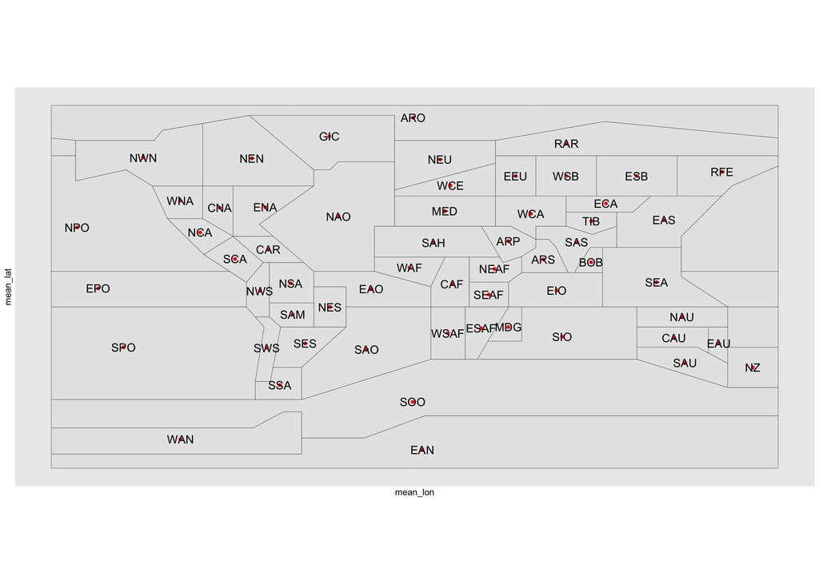

# Load ESM data that’s been processed

```r
region_summary_main <- read.csv(paste0(metrics_write_dir, 'IPCC_land_regions_allESMs_ensavg_tp_metrics.csv'),
                                stringsAsFactors = FALSE)
region_summary_main %>%
  filter(experiment != 'ssp119',
         experiment != 'ssp434',
         experiment != 'ssp460',
         experiment != 'ssp534-over') ->
  region_summary

print(head(region_summary))
```

```
##           esm experiment region      iasd tas_change    pr_pct
## 1 CAMS-CSM1-0     ssp126    ARP 0.3310797  0.7217781 10.495059
## 2 CAMS-CSM1-0     ssp126    CAF 0.3406182  0.6534092  2.542290
## 3 CAMS-CSM1-0     ssp126    CAR 0.1843266  0.4755080 -3.296680
## 4 CAMS-CSM1-0     ssp126    CAU 0.4651680  0.7300895  3.032642
## 5 CAMS-CSM1-0     ssp126    CNA 0.5538641  0.7759938  4.609668
## 6 CAMS-CSM1-0     ssp126    EAS 0.3169825  0.9085901  3.753970
```

# Prep data for PCA

- idea is that there’s something really similar across ESMs, especially for SSP126/245 -> their RGB maps have so much in common.
- is there a sort of core map that gets deviations added to as you move through scenarios and ESMs? Or how many distinct maps do we actually have
- And the aim of the archive is to establish that our selection of ESMs forms a spanning set of vectors for all/most of CMIP6
- observation = scenarioXesm
- individual variable is a regionXmetric
- so each observation vector is `3*Nregions` long: `<Tr1...Trn, Pr1...Prn, IASDr1...IASDrn >` for a scenarioXesm <-> there are 48 observations for each of 129 variables
- And then becaues we’re interested in a pseudo-basis for the CMIP6 archive, we want the training data to be all scenarios and ESMs
- Out of sample tests -> how does basis do on overshoots that it doesn’t train on; withhold one of the 12 ESMs and learn from other 11 to see how it goes; then see how a completely external ESM does on training from all 12
- nothing *a priori* to preclude us from doing EOFs on the gridded time series data, or the gridded metrics, but having on IPCC regions avoids the issue of all ESMs being on their own grids
- and overall doing region metrics helps keep data size operating on manageable

```r
# reshape:
grouped_data <- split(region_summary, list(region_summary$esm, region_summary$experiment))

shaped_data <- lapply(grouped_data, function(group){

  group %>%
    select(esm, experiment, region, tas_change) %>%
    mutate(metric = 'tas_change') %>%
    rename(value = tas_change) %>%
    bind_rows( group %>%
                 select(esm, experiment, region, pr_pct) %>%
                 mutate(metric = 'pr_pct') %>%
                 rename(value = pr_pct),
               group %>%
                 select(esm, experiment, region, iasd) %>%
                 mutate(metric = 'iasd') %>%
                 rename(value = iasd)
               ) ->
    reshaped

  reshaped %>%
    mutate(row_id = paste0(region, '~', metric),
           col_id = paste0(esm, '~', experiment)) %>%
    select(-esm, -experiment, -region, -metric)->
    reshaped2

  colnames(reshaped2) <- c(paste0(unique(reshaped2$col_id)), 'row_id', 'col_id')
  rownames(reshaped2) <- paste0(reshaped2$row_id)

  reshaped2 %>%
    select(-col_id, -row_id) ->
    out

  return(out)

  }
)

# combine columns but then transpose because prcomp wants rows to be observations
# and columns to be variables (but doing it the other way first is easier to code)
data <- t(do.call(cbind, shaped_data) )

print(head(data))
```

```
##                      ARP~tas_change CAF~tas_change CAR~tas_change
## ACCESS-ESM1-5~ssp126      2.0934292      1.4062035      1.2637948
## CAMS-CSM1-0~ssp126        0.7217781      0.6534092      0.4755080
## CanESM5~ssp126            1.8852330      1.4174536      1.2169352
## CESM2-WACCM~ssp126        1.3786494      1.5680946      1.1636474
## FGOALS-g3~ssp126          0.5764236      0.4784259      0.3660500
## GFDL-ESM4~ssp126          0.8411439      0.8912358      0.5852106
##                      CAU~tas_change CNA~tas_change EAS~tas_change
## ACCESS-ESM1-5~ssp126      1.4220469      1.9358447      2.0989347
## CAMS-CSM1-0~ssp126        0.7300895      0.7759938      0.9085901
## CanESM5~ssp126            1.5954996      2.3281459      1.8941794
## CESM2-WACCM~ssp126        1.9348767      2.1549397      1.5537137
## FGOALS-g3~ssp126          0.6114476      1.0052793      0.8390909
## GFDL-ESM4~ssp126          0.7623585      1.3529410      1.1177500
##                      EAU~tas_change ECA~tas_change EEU~tas_change
## ACCESS-ESM1-5~ssp126      1.2895340      2.1831134      2.2892746
## CAMS-CSM1-0~ssp126        0.7745160      1.2119103      0.9167158
## CanESM5~ssp126            1.3152452      2.3901285      2.5315036
## CESM2-WACCM~ssp126        1.5581398      1.6295139      1.8464658
## FGOALS-g3~ssp126          0.5094309      0.6871101      1.1511501
## GFDL-ESM4~ssp126          0.6682136      1.0434035      1.2996841
##                      ENA~tas_change ESAF~tas_change ESB~tas_change
## ACCESS-ESM1-5~ssp126      1.9531506       1.4106781      2.2502906
## CAMS-CSM1-0~ssp126        0.8043893       0.7667614      1.0212179
## CanESM5~ssp126            2.1455629       1.3633206      2.4667860
## CESM2-WACCM~ssp126        1.9160322       1.5008813      1.6024391
## FGOALS-g3~ssp126          0.7230922       0.4964863      0.8714566
## GFDL-ESM4~ssp126          1.0638501       0.8287609      1.1677105
##                      MDG~tas_change MED~tas_change NAU~tas_change
## ACCESS-ESM1-5~ssp126      1.0452862      1.9713492      1.1089889
## CAMS-CSM1-0~ssp126        0.6119823      0.8296688      0.6303114
## CanESM5~ssp126            1.0390257      1.8284683      1.1681050
## CESM2-WACCM~ssp126        1.3760163      1.0973002      1.2702710
## FGOALS-g3~ssp126          0.3929008      0.6431663      0.4203934
## GFDL-ESM4~ssp126          0.5653914      0.6991397      0.6855748
##                      NCA~tas_change NEAF~tas_change NEN~tas_change
## ACCESS-ESM1-5~ssp126      1.5912180       1.5358975      2.7149723
## CAMS-CSM1-0~ssp126        0.6633229       0.7093529      0.9960863
## CanESM5~ssp126            1.5765876       1.3340496      4.5553824
## CESM2-WACCM~ssp126        1.2676374       1.5218842      1.9760455
```

[output cut: 162 more lines]

```
## GFDL-ESM4~ssp126     0.2543625 0.2268227 0.2344991 0.1495815 0.2345583
##                       SES~iasd  SSA~iasd  SWS~iasd  TIB~iasd  WAF~iasd
## ACCESS-ESM1-5~ssp126 0.2903325 0.2412129 0.2617533 0.2807335 0.2708157
## CAMS-CSM1-0~ssp126   0.3586119 0.2553562 0.3066687 0.4298224 0.3152778
## CanESM5~ssp126       0.3143773 0.2042021 0.2596287 0.5149744 0.2499668
## CESM2-WACCM~ssp126   0.3225192 0.2416382 0.3346728 0.3579184 0.3364580
## FGOALS-g3~ssp126     0.2496672 0.2825341 0.2145532 0.3522739 0.2154399
## GFDL-ESM4~ssp126     0.3228440 0.2765938 0.2860680 0.3419883 0.2473492
##                       WCA~iasd  WCE~iasd  WNA~iasd WSAF~iasd  WSB~iasd
## ACCESS-ESM1-5~ssp126 0.3764538 0.5743571 0.4623572 0.2658966 0.6660748
## CAMS-CSM1-0~ssp126   0.5181384 0.6235452 0.4666619 0.2425287 0.7592543
## CanESM5~ssp126       0.4565611 0.5088701 0.5542324 0.2544136 0.7561828
## CESM2-WACCM~ssp126   0.4298636 0.6125324 0.5337985 0.3138779 0.8537584
## FGOALS-g3~ssp126     0.4189535 0.7259719 0.5703651 0.2247946 0.8483985
## GFDL-ESM4~ssp126     0.3961498 0.6131900 0.4419899 0.3016356 0.6515188
```

# do PCA

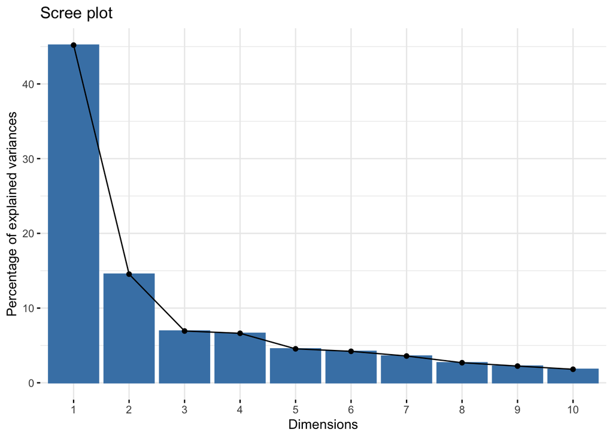

```r
data_pca <- prcomp(data, center=TRUE, scale = TRUE)

# quick visualize
factoextra::fviz_eig(data_pca)
```

## further visualization

```r
# coordinates of each ESM-SSP combo in the PCs
data_pca$x %>%
  as.data.frame() %>%
  mutate(id = row.names(.)) %>%
  separate(id, into=c('model', 'scenario'), sep = '~') %>%
  select(model, scenario, PC1, PC2, PC3, PC4, PC5, PC6, PC7, PC8, PC9)->
  coordinates
```

## PC1 vs PC2

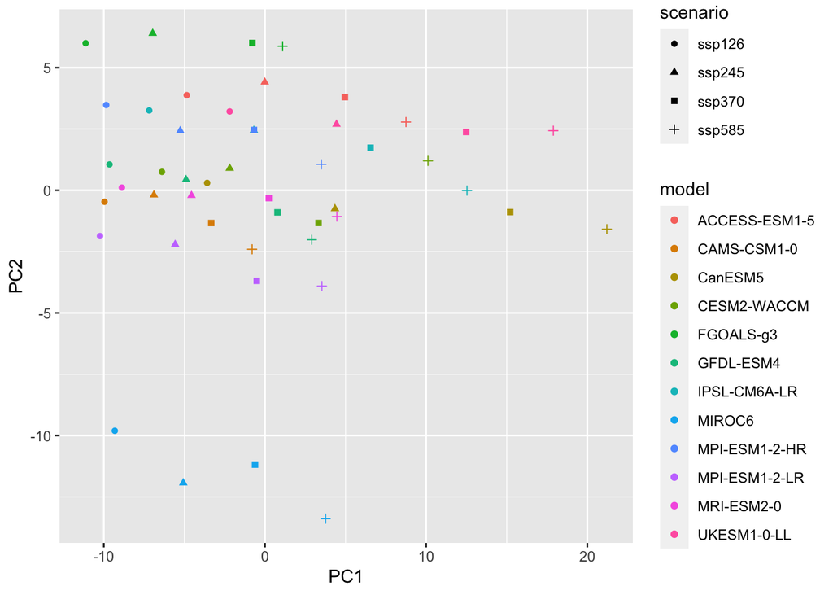

```r
ggplot(coordinates) +
  geom_point(mapping = aes(x = PC1, y = PC2, color = model, shape = scenario))
```

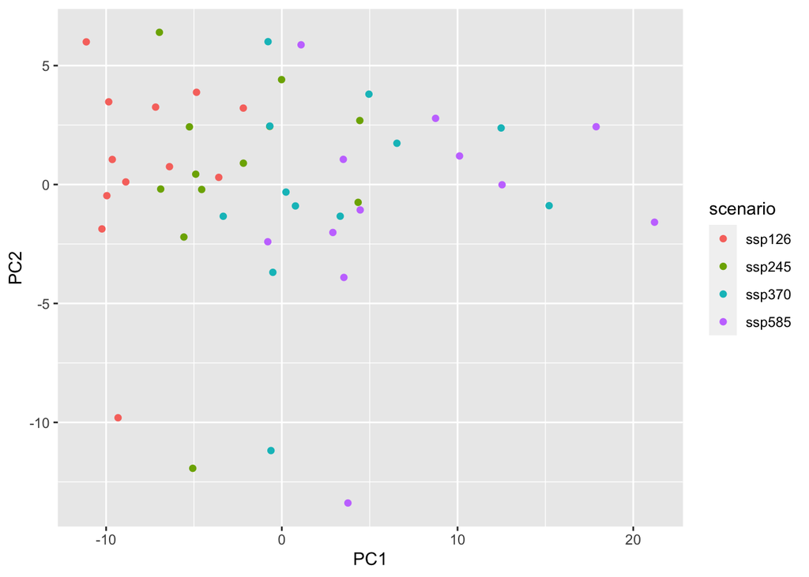

```r
ggplot(coordinates) +
  geom_point(mapping = aes(x = PC1, y = PC2, color = scenario))
```

## PC1 vs PC3

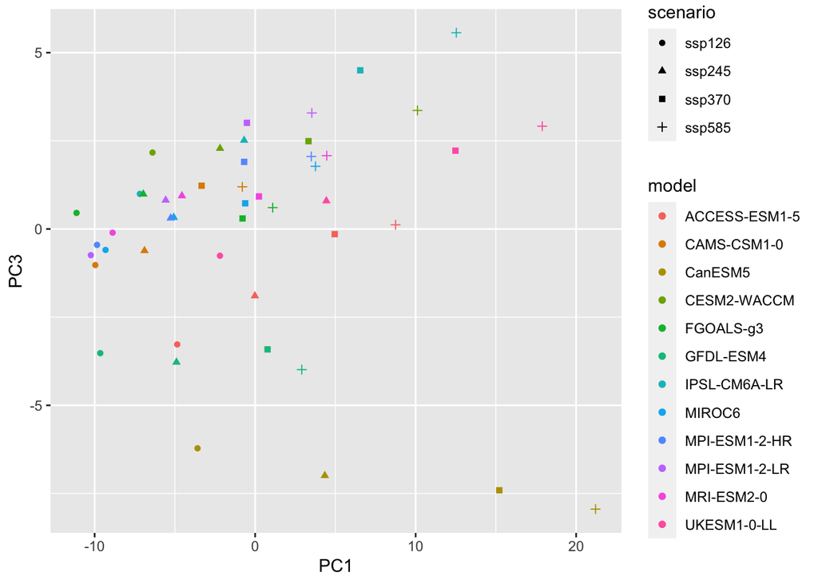

```r
ggplot(coordinates) +
  geom_point(mapping = aes(x = PC1, y = PC3, color = model, shape = scenario))
```

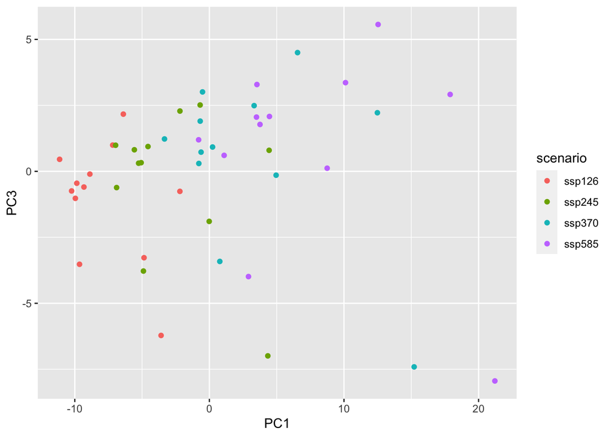

```r
ggplot(coordinates) +
  geom_point(mapping = aes(x = PC1, y = PC3, color = scenario))
```

## PC1 vs PC4

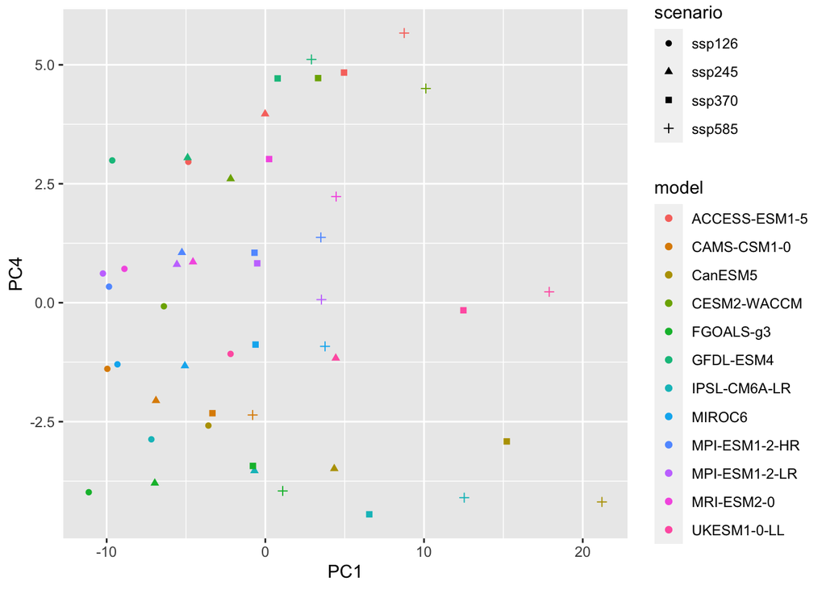

```r
ggplot(coordinates) +
  geom_point(mapping = aes(x = PC1, y = PC4, color = model, shape = scenario))
```

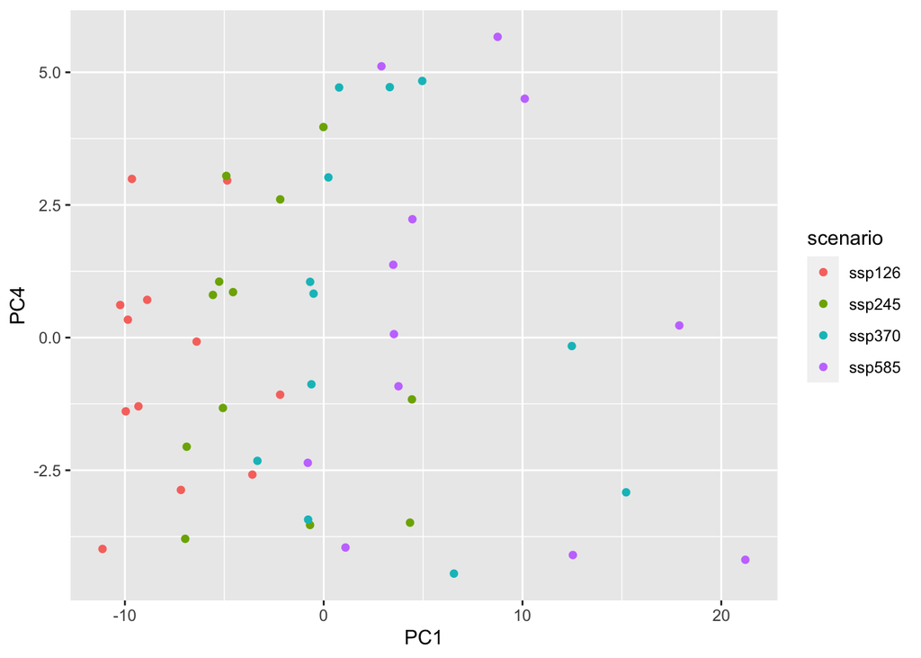

```r
ggplot(coordinates) +
  geom_point(mapping = aes(x = PC1, y = PC4, color = scenario))
```

## PC2 vs PC3

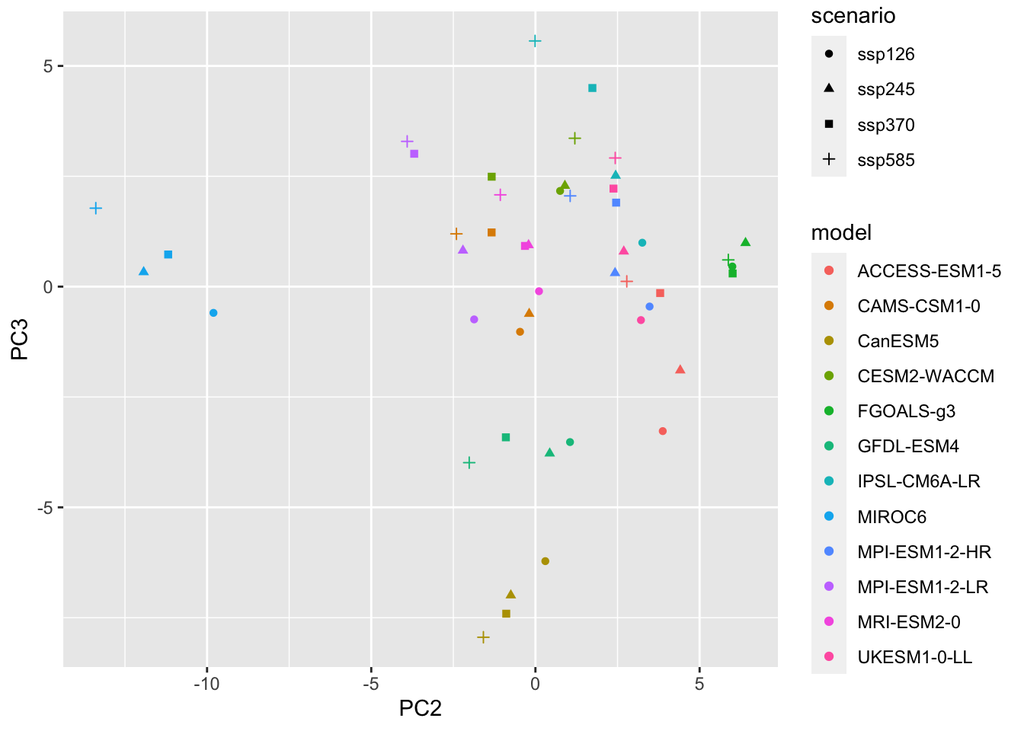

```r
ggplot(coordinates) +
  geom_point(mapping = aes(x = PC2, y = PC3, color = model, shape = scenario))
```

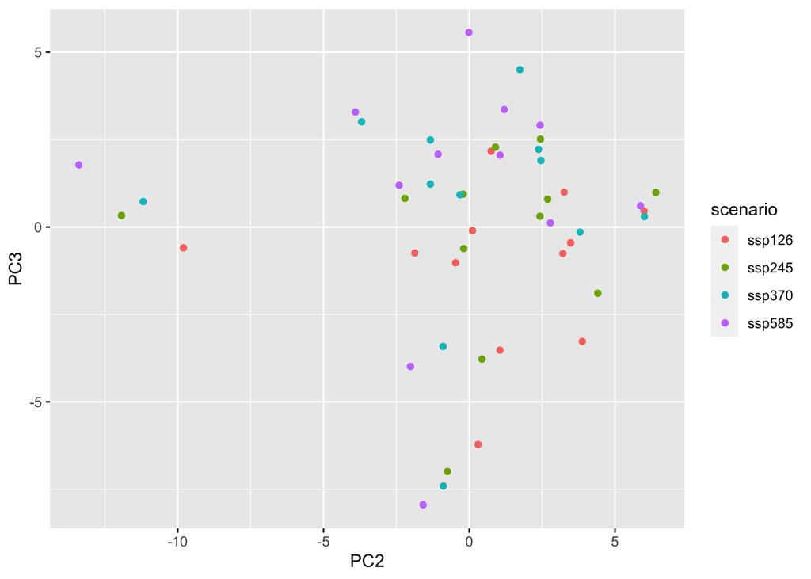

```r
ggplot(coordinates) +
  geom_point(mapping = aes(x = PC2, y = PC3, color = scenario))
```

## PC2 vs PC4

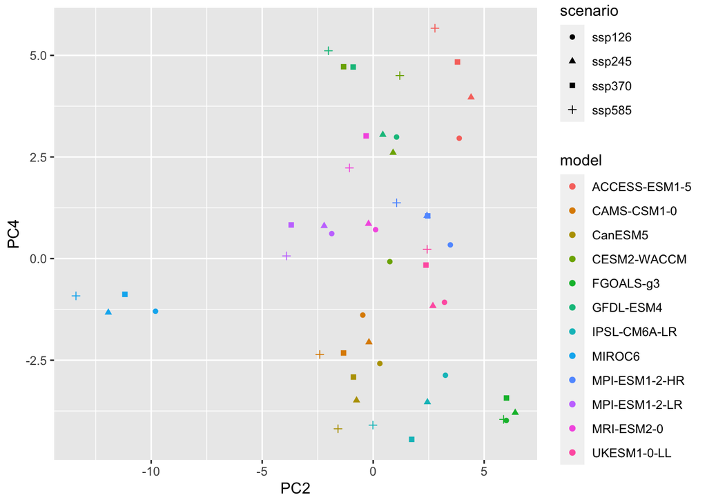

```r
ggplot(coordinates) +
  geom_point(mapping = aes(x = PC2, y = PC4, color = model, shape = scenario))
```

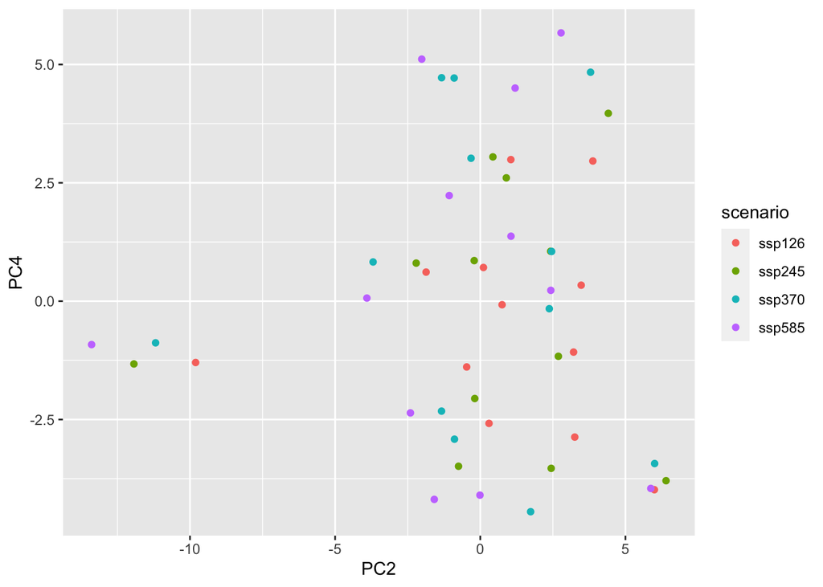

```r
ggplot(coordinates) +
  geom_point(mapping = aes(x = PC2, y = PC4, color = scenario))
```

## PC3 vs PC4

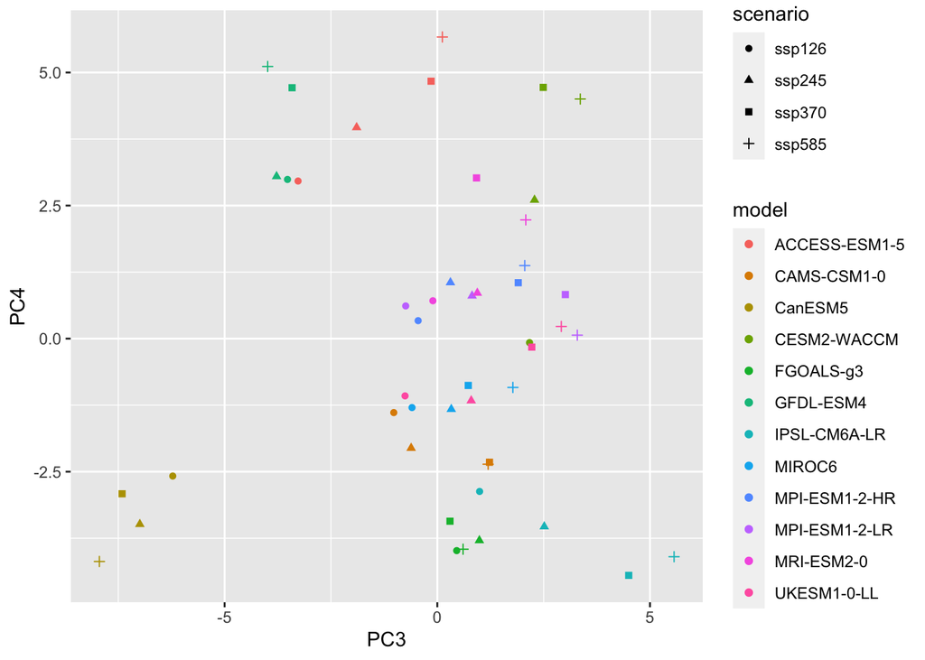

```r
ggplot(coordinates) +
  geom_point(mapping = aes(x = PC3, y = PC4, color = model, shape = scenario))
```

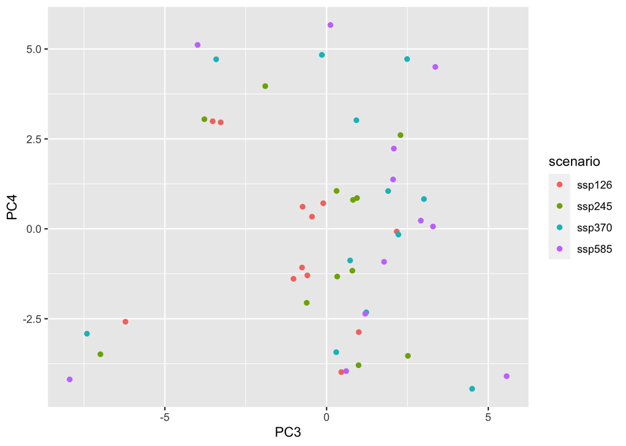

```r
ggplot(coordinates) +
  geom_point(mapping = aes(x = PC3, y = PC4, color = scenario))
```

## plot as map

```r
pcs <- data_pca$rotation

str(pcs)
```

```
##  num [1:129, 1:48] 0.13 0.125 0.129 0.128 0.128 ...
##  - attr(*, "dimnames")=List of 2
##   ..$ : chr [1:129] "ARP~tas_change" "CAF~tas_change" "CAR~tas_change" "CAU~tas_change" ...
##   ..$ : chr [1:48] "PC1" "PC2" "PC3" "PC4" ...
```

```r
# pull the region and metric info back in
as.data.frame(pcs) %>%
  mutate(row_id = row.names(.)) %>%
  separate(row_id, into = c('region', 'metric'), sep ='~') ->
  tmp


# We want to convert each set of 3 metrics in a region to a single
# rgb coded value.
# and we want all on same color scale.

# so reshape for each metric (which goes to one of r, g, b)
# with all PCs want to consider stacked.
tmp %>%
  filter(metric == 'tas_change') %>%
  select(region, metric, PC1) %>%
  rename(tas_change = PC1) %>%
  mutate(pc = 'PC1') %>%
    bind_rows(tmp %>%
                filter(metric == 'tas_change') %>%
                select(region, metric, PC2) %>%
                rename(tas_change = PC2) %>%
                mutate(pc = 'PC2'),
              tmp %>%
                filter(metric == 'tas_change') %>%
                select(region, metric, PC3) %>%
                rename(tas_change = PC3) %>%
                mutate(pc = 'PC3') ,
              tmp %>%
                filter(metric == 'tas_change') %>%
                select(region, metric, PC4) %>%
                rename(tas_change = PC4) %>%
                mutate(pc = 'PC4'),
              tmp %>%
                filter(metric == 'tas_change') %>%
                select(region, metric, PC5) %>%
                rename(tas_change = PC5) %>%
                mutate(pc = 'PC5'),
              tmp %>%
                filter(metric == 'tas_change') %>%
                select(region, metric, PC6) %>%
                rename(tas_change = PC6) %>%
                mutate(pc = 'PC6'),
              tmp %>%
                filter(metric == 'tas_change') %>%
                select(region, metric, PC7) %>%
                rename(tas_change = PC7) %>%
                mutate(pc = 'PC7'),
              tmp %>%
                filter(metric == 'tas_change') %>%
                select(region, metric, PC8) %>%
                rename(tas_change = PC8) %>%
                mutate(pc = 'PC8'),
              tmp %>%
                filter(metric == 'tas_change') %>%
                select(region, metric, PC9) %>%
                rename(tas_change = PC9) %>%
                mutate(pc = 'PC9'),
              tmp %>%
                filter(metric == 'tas_change') %>%
                select(region, metric, PC10) %>%
                rename(tas_change = PC10) %>%
                mutate(pc = 'PC10')
              ) ->
  tas
print(head(tas))
```

```
##                    region     metric tas_change  pc
## ARP~tas_change...1    ARP tas_change  0.1298692 PC1
## CAF~tas_change...2    CAF tas_change  0.1251125 PC1
## CAR~tas_change...3    CAR tas_change  0.1287444 PC1
## CAU~tas_change...4    CAU tas_change  0.1282287 PC1
## CNA~tas_change...5    CNA tas_change  0.1282116 PC1
## EAS~tas_change...6    EAS tas_change  0.1293579 PC1
```

```r
print(tail(tas))
```

```
##                       region     metric    tas_change   pc
## WAF~tas_change...425     WAF tas_change  0.0163938075 PC10
## WCA~tas_change...426     WCA tas_change  0.0074053689 PC10
## WCE~tas_change...427     WCE tas_change -0.0352215926 PC10
## WNA~tas_change...428     WNA tas_change  0.0165908711 PC10
## WSAF~tas_change...429   WSAF tas_change -0.0165551020 PC10
## WSB~tas_change...430     WSB tas_change  0.0009282167 PC10
```

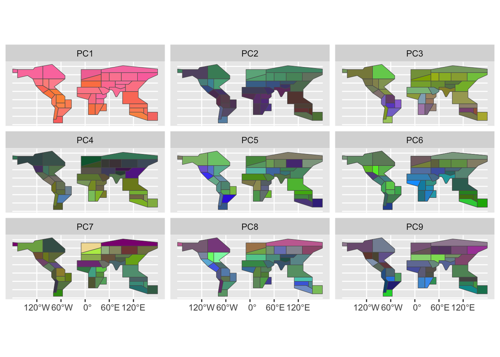

```r
tmp %>%
  filter(metric == 'pr_pct') %>%
  select(region, metric, PC1) %>%
  rename(pr_pct = PC1) %>%
  mutate(pc = 'PC1') %>%
  bind_rows(tmp %>%
              filter(metric == 'pr_pct') %>%
              select(region, metric, PC2) %>%
              rename(pr_pct = PC2) %>%
              mutate(pc = 'PC2'),
            tmp %>%
              filter(metric == 'pr_pct') %>%
              select(region, metric, PC3) %>%
              rename(pr_pct = PC3) %>%
              mutate(pc = 'PC3') ,
            tmp %>%
              filter(metric == 'pr_pct') %>%
              select(region, metric, PC4) %>%
              rename(pr_pct = PC4) %>%
              mutate(pc = 'PC4') ,
            tmp %>%
              filter(metric == 'pr_pct') %>%
              select(region, metric, PC5) %>%
              rename(pr_pct = PC5) %>%
              mutate(pc = 'PC5') ,
            tmp %>%
              filter(metric == 'pr_pct') %>%
              select(region, metric, PC6) %>%
              rename(pr_pct = PC6) %>%
              mutate(pc = 'PC6') ,
            tmp %>%
              filter(metric == 'pr_pct') %>%
              select(region, metric, PC7) %>%
              rename(pr_pct = PC7) %>%
              mutate(pc = 'PC7') ,
            tmp %>%
              filter(metric == 'pr_pct') %>%
              select(region, metric, PC8) %>%
              rename(pr_pct = PC8) %>%
              mutate(pc = 'PC8') ,
            tmp %>%
              filter(metric == 'pr_pct') %>%
              select(region, metric, PC9) %>%
              rename(pr_pct = PC9) %>%
              mutate(pc = 'PC9') ,
            tmp %>%
              filter(metric == 'pr_pct') %>%
              select(region, metric, PC10) %>%
              rename(pr_pct = PC10) %>%
              mutate(pc = 'PC10')
              ) ->
  pr


tmp %>%
  filter(metric == 'iasd') %>%
  select(region, metric, PC1) %>%
  rename(iasd = PC1) %>%
  mutate(pc = 'PC1') %>%
  bind_rows(tmp %>%
              filter(metric == 'iasd') %>%
              select(region, metric, PC2) %>%
              rename(iasd = PC2) %>%
              mutate(pc = 'PC2'),
            tmp %>%
              filter(metric == 'iasd') %>%
              select(region, metric, PC3) %>%
              rename(iasd = PC3) %>%
              mutate(pc = 'PC3') ,
            tmp %>%
              filter(metric == 'iasd') %>%
              select(region, metric, PC4) %>%
              rename(iasd = PC4) %>%
              mutate(pc = 'PC4') ,
            tmp %>%
              filter(metric == 'iasd') %>%
              select(region, metric, PC5) %>%
              rename(iasd = PC5) %>%
              mutate(pc = 'PC5'),
            tmp %>%
              filter(metric == 'iasd') %>%
              select(region, metric, PC6) %>%
              rename(iasd = PC6) %>%
              mutate(pc = 'PC6'),
            tmp %>%
              filter(metric == 'iasd') %>%
              select(region, metric, PC6) %>%
              rename(iasd = PC6) %>%
              mutate(pc = 'PC6'),
            tmp %>%
              filter(metric == 'iasd') %>%
              select(region, metric, PC7) %>%
              rename(iasd = PC7) %>%
              mutate(pc = 'PC7'),
            tmp %>%
              filter(metric == 'iasd') %>%
              select(region, metric, PC8) %>%
              rename(iasd = PC8) %>%
              mutate(pc = 'PC8'),
            tmp %>%
              filter(metric == 'iasd') %>%
              select(region, metric, PC9) %>%
              rename(iasd = PC9) %>%
              mutate(pc = 'PC9'),
            tmp %>%
              filter(metric == 'iasd') %>%
              select(region, metric, PC10) %>%
              rename(iasd = PC10) %>%
              mutate(pc = 'PC10')
              ) ->
iasd


tas %>%
  select(-metric) %>%
  left_join(pr %>% select(-metric), by =c('region', 'pc')) %>%
  left_join(iasd %>% select(-metric), by =c('region', 'pc')) ->
  colored_pcs


colored_pcs$r <- scales::rescale(colored_pcs$tas_change, to =c(0,255))
colored_pcs$g <- scales::rescale(colored_pcs$iasd, to =c(0,255))
colored_pcs$b <- scales::rescale(colored_pcs$pr_pct, to =c(0,255))

colored_pcs %>%
  left_join(as.data.frame(shp) %>% select(Acronym, mean_lon, mean_lat), by = c('region' = 'Acronym')) %>%
  rename(lon  = mean_lon, lat = mean_lat) %>%
  mutate(color = rgb(.$r, .$g, .$b, maxColorValue  = 255),
         color_order = as.integer(row.names(.))) ->
  pc_plotting

pc_plotting %>%
  select(color_order, color) %>%
  distinct() ->
  colors

shp %>%
  left_join(pc_plotting, by = c('Acronym' = 'region'))->
  shp_pcs

p<- ggplot() +
  geom_sf(data = shp_pcs %>% filter(pc != 'PC10') %>% na.omit, aes(fill = as.factor(color_order)) ) +
  scale_fill_manual(values =colors$color)+
  facet_wrap(~pc, ncol=3) +
  theme(legend.position = 'none')
p
```

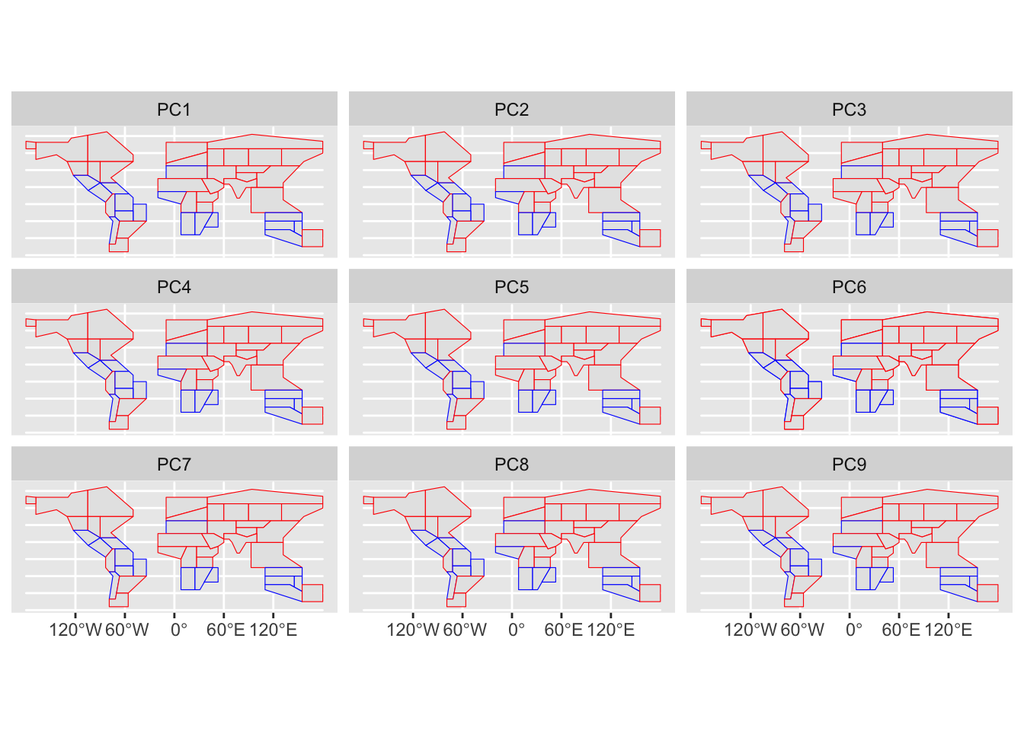

```r
#look at whether Precip inc or dec -> not just the PCs' precip entries >= 0
# because standardized/

as.data.frame(data_pca$center) %>%
  mutate(row_id = row.names(.)) %>%
  filter(grepl('pr_pct', row_id)) %>%
  separate(row_id, into  = c('region', 'trash'), sep = '~') %>%
  select(-trash) ->
  pr_centers

as.data.frame(data_pca$scale) %>%
  mutate(row_id = row.names(.)) %>%
  filter(grepl('pr_pct', row_id)) %>%
  separate(row_id, into  = c('region', 'trash'), sep = '~') %>%
  select(-trash) ->
  pr_scales




shp_pcs %>%
  left_join(pr_centers, by = c('Acronym'='region')) %>%
  left_join(pr_scales, by = c('Acronym'='region')) %>%
  mutate(precip_change = if_else( ((pr_pct*`data_pca$scale`)- `data_pca$center`) >=0, 'inc', 'dec'))->
  shp_pcs2


ggplot() +
    geom_sf(data = shp_pcs2 %>% filter(pc != 'PC10') %>% na.omit, aes(#fill = as.factor(color_order),
                                             color = precip_change )) +
  #scale_fill_manual(values =colors$orig_color)+
  scale_color_manual(values = c('red', 'blue'))+
  facet_wrap(~pc, ncol=3) +
  theme(legend.position = 'none')
```

# predict

Is this set of 12 ESMs and 4 scenarios a spanning set - can I use the basis estimated from these 48 observations to do a credible job producing the metrics for an out of sample ESM or Scenario?

## withheld experiments - ssp460

```r
# pull off and reshape the ssp460 data
region_summary_main %>%
  filter(experiment == 'ssp460') ->
  region_460

# reshape:
grouped_data <- split(region_460, list(region_460$esm, region_460$experiment))

shaped_data <- lapply(grouped_data, function(group){

  group %>%
    select(esm, experiment, region, tas_change) %>%
    mutate(metric = 'tas_change') %>%
    rename(value = tas_change) %>%
    bind_rows( group %>%
                 select(esm, experiment, region, pr_pct) %>%
                 mutate(metric = 'pr_pct') %>%
                 rename(value = pr_pct),
               group %>%
                 select(esm, experiment, region, iasd) %>%
                 mutate(metric = 'iasd') %>%
                 rename(value = iasd)
               ) ->
    reshaped

  reshaped %>%
    mutate(row_id = paste0(region, '~', metric),
           col_id = paste0(esm, '~', experiment)) %>%
    select(-esm, -experiment, -region, -metric)->
    reshaped2

  colnames(reshaped2) <- c(paste0(unique(reshaped2$col_id)), 'row_id', 'col_id')
  rownames(reshaped2) <- paste0(reshaped2$row_id)

  reshaped2 %>%
    select(-col_id, -row_id) ->
    out

  return(out)

  }
)

# combine columns but then transpose because prcomp wants rows to be observations
# and columns to be variables (but doing it the other way first is easier to code)
data_460 <- t(do.call(cbind, shaped_data) )

print(head(data_460))


data_460_coords <- predict(data_pca, newdata = data_460)

print(head(data_460_coords))
```

[output not shown]

```r
# Plot of active individuals
p <- fviz_pca_ind(data_pca, repel = TRUE)
# Add supplementary individuals
fviz_add(p, data_460_coords, color ="blue")
```

[output not shown]

- compare the ‘true’ data with projected data?

```r
recons_460 <- data_460_coords %*% t(pcs)

as.data.frame(recons_460) %>%
  mutate(row_id = row.names(.)) %>%
  separate(row_id, c('esm', 'experiment'), sep = '~') %>%
  gather(rgn_metric, recons_value, - esm, -experiment) %>%
  separate(rgn_metric, c('region', 'metric'), sep = '~')  %>%
  # add the center and scale info, then de-standardize
  ->
  shaped_recons_460

as.data.frame(data_460) %>%
  mutate(row_id = row.names(.)) %>%
  separate(row_id, c('esm', 'experiment'), sep = '~') %>%
  gather(rgn_metric, value, - esm, -experiment) %>%
  separate(rgn_metric, c('region', 'metric'), sep = '~') %>%
  left_join(shaped_recons_460, by = c('esm', 'experiment', 'region', 'metric')) ->
 comparison
```

## withold an ESM and test:

- make reshaping a function
- reshape just like first 4 ESMs
- predict others

# Other ideas

- 4 PCs for each ESM and compare those? hard to visualize at that point though
- compute basis with all esm data and find invariant subspaces?